Lake Name: Lake Petonia

Lake acreage: 24.1

County: CHENANGO

PWLID: 0602-0092

Waterbody Classification: A

Coordinates: 42.331699,-75.7985

Is this waterbody a public water supply: No

Are there DOH desingated beaches on this waterbody: No

Open Water Indicators

2018 Sampling Results

Seasonal Change

06-07

06-24

07-13

07-26

08-10

08-24

09-13

09-29

Clarity (m)

7.75

7.00

5.55

5.40

4.90

4.45

3.85

2.30

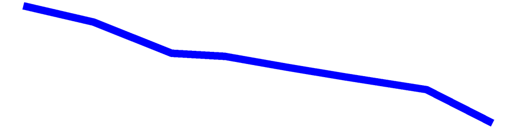

Surface TP (mg/L)

0.01

0.01

0.00

0.01

0.00

0.01

0.01

0.01

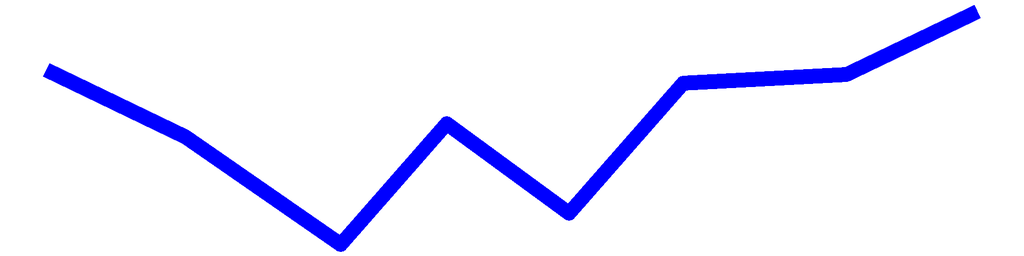

Surface TDP (mg/L)

0.00

0.01

0.01

0.00

0.00

0.00

0.00

0.00

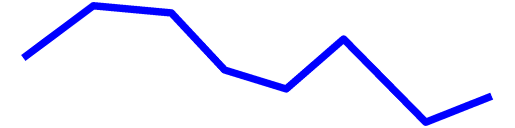

Deep TP (mg/L)

0.01

0.01

0.01

0.01

0.01

0.02

0.01

0.01

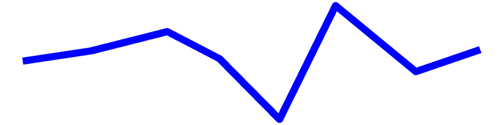

Deep TDP (mg/L)

0.00

0.01

0.01

0.01

0.00

0.00

0.01

0.00

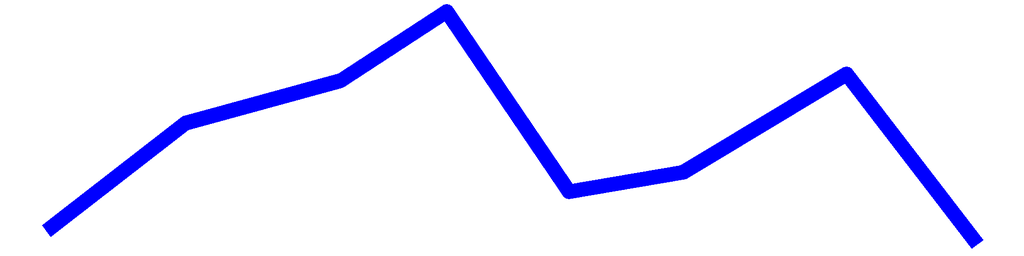

TN (mg/L)

0.31

0.39

0.26

0.34

0.30

0.31

0.29

0.28

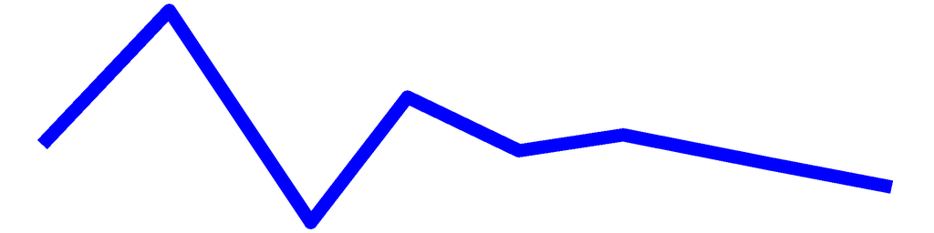

TDN (mg/L)

0.32

0.38

0.26

0.38

0.30

0.34

0.31

0.27

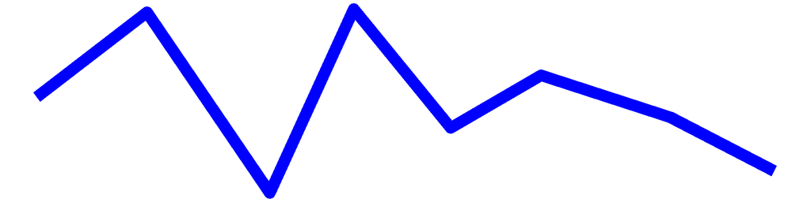

TN:TP

37.74

58.99

61.19

48.60

61.56

39.96

36.67

29.68

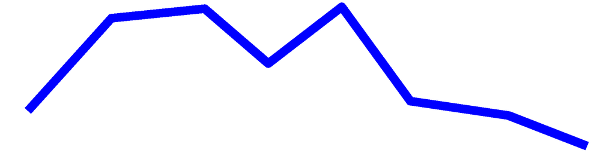

Surface NH3 (mg/L)

0.02

0.02

0.02

0.02

0.02

0.01

0.00

0.00

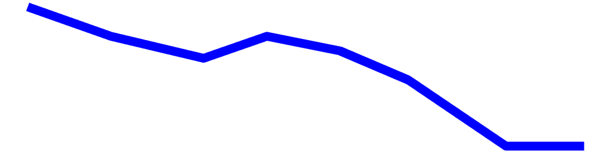

Deep NH3 (mg/L)

0.02

0.07

0.03

0.06

0.10

0.02

0.02

0.00

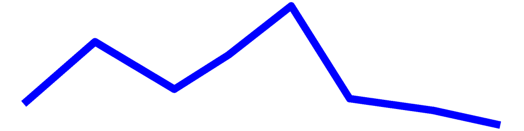

Chl.a (ug/L)

1.00

2.00

0.40

1.10

4.70

3.40

8.30

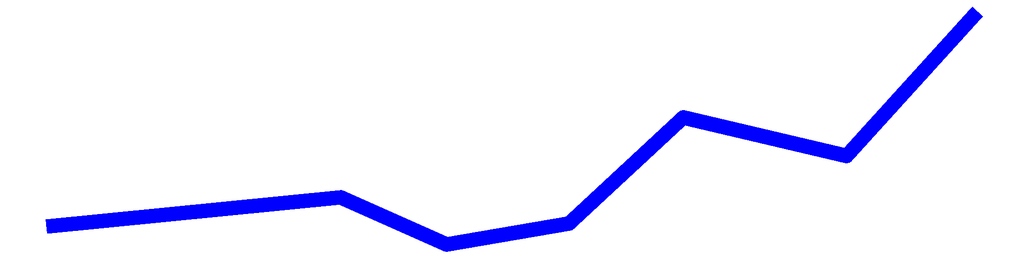

pH

6.83

6.89

7.91

7.00

7.58

7.75

7.11

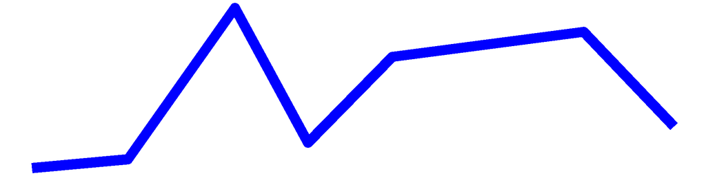

Cond (umho/cm)

89.30

83.60

85.80

80.20

78.90

74.20

79.50

77.80

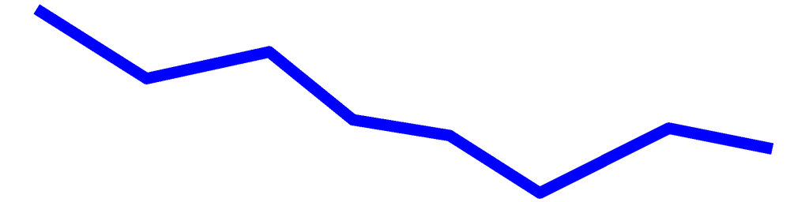

Surface Calcium (mg/L)

Bottom Calcium (mg/L)

Surface Chloride (mg/L)

19.70

18.10

Bottom Chloride (mg/L)

Upper Temp (degC)

18.00

22.00

25.00

26.00

26.00

26.00

26.00

21.00

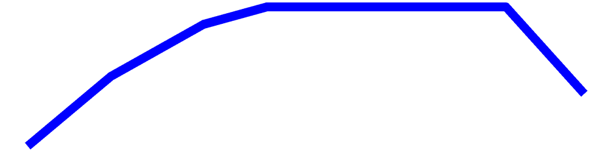

Deep Temp (degC)

16.00

11.00

18.00

18.00

19.00

22.50

23.00

21.00

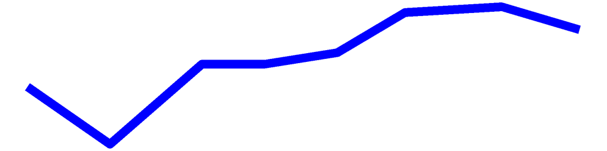

FP BG Chl.a (ug/L)

1.17

4.06

2.70

4.15

3.07

9.48

11.62

19.93

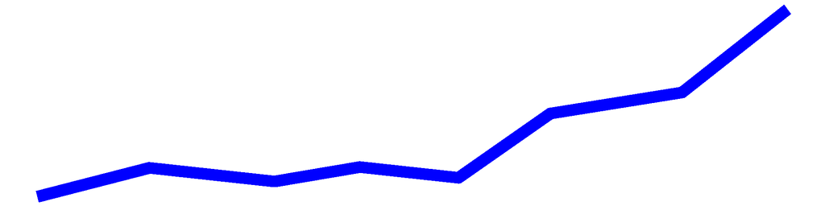

## Lake Petonia – Sampling Season Results

### HABs Status

#### Open Water Algae

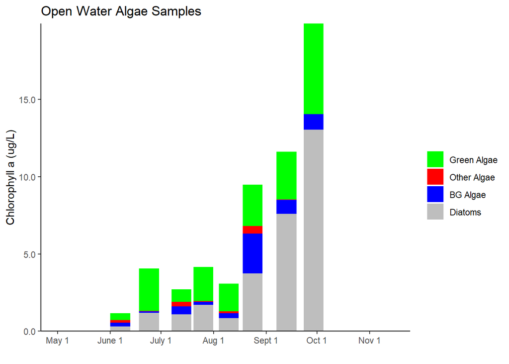

## Lake Petonia Long-Term Trend Analysis

#### Clarity

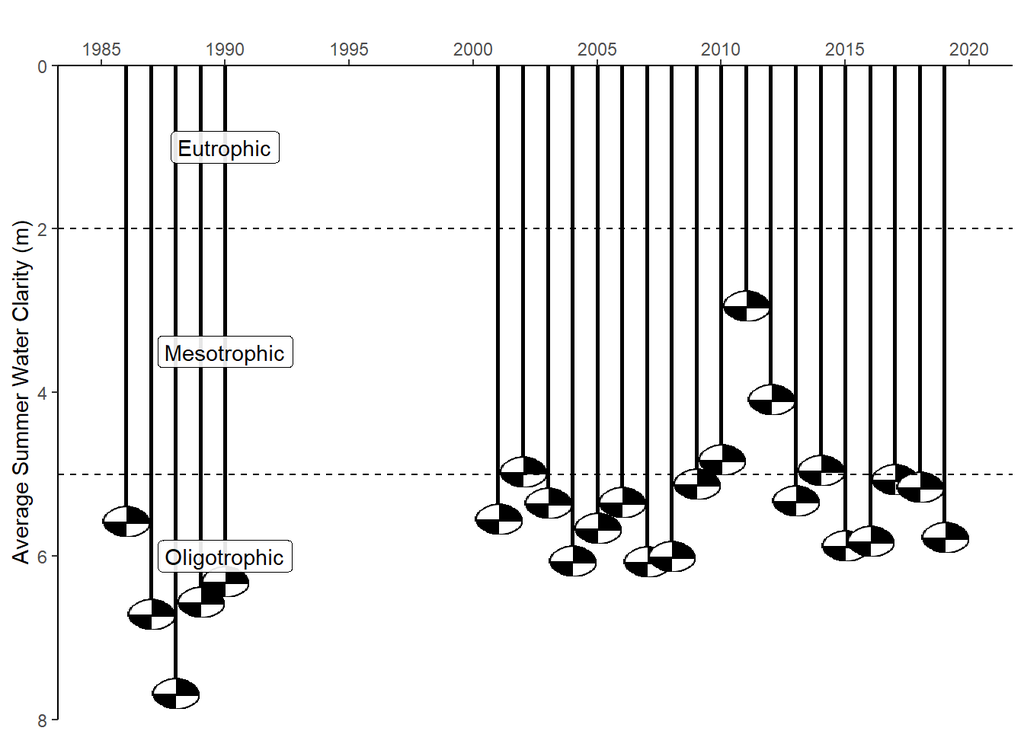

#### Chlorophyll *a*

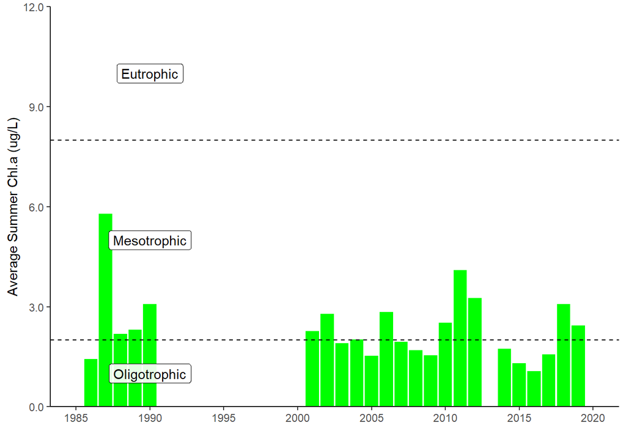

#### Surface and Deep Phosphorus

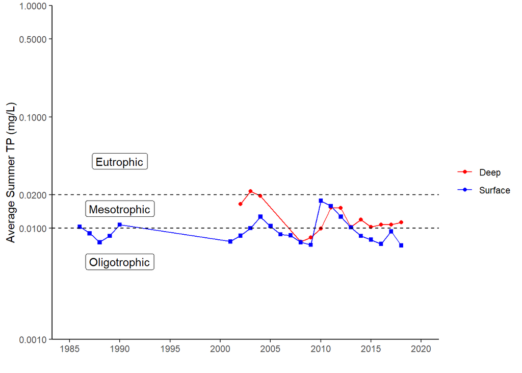

#### Nitrogen

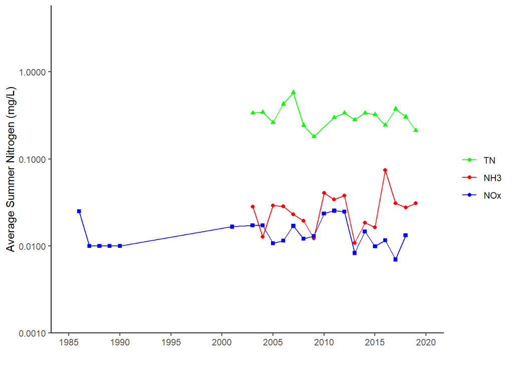

#### TN : TP

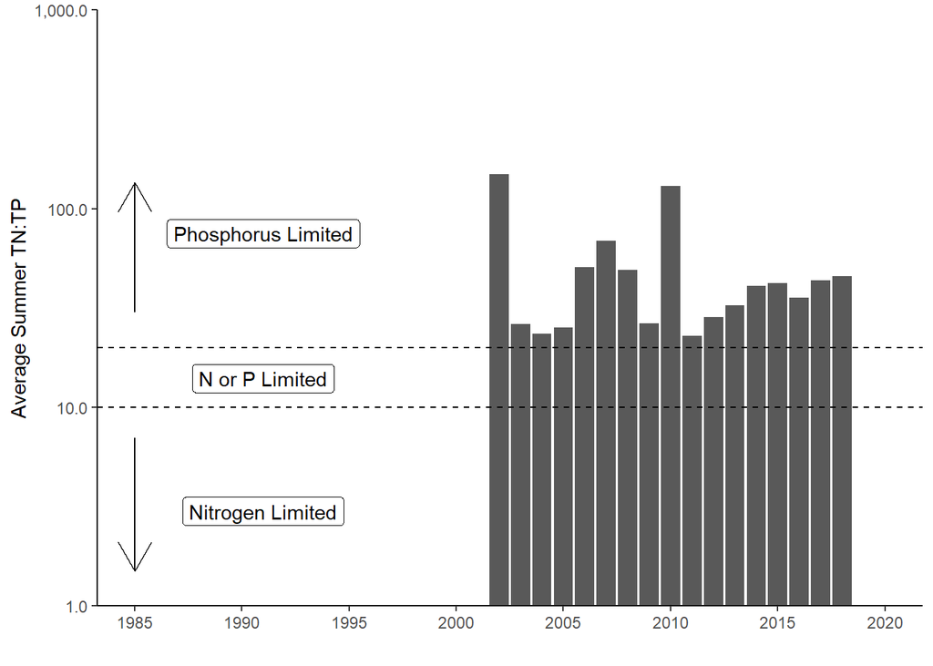

#### pH

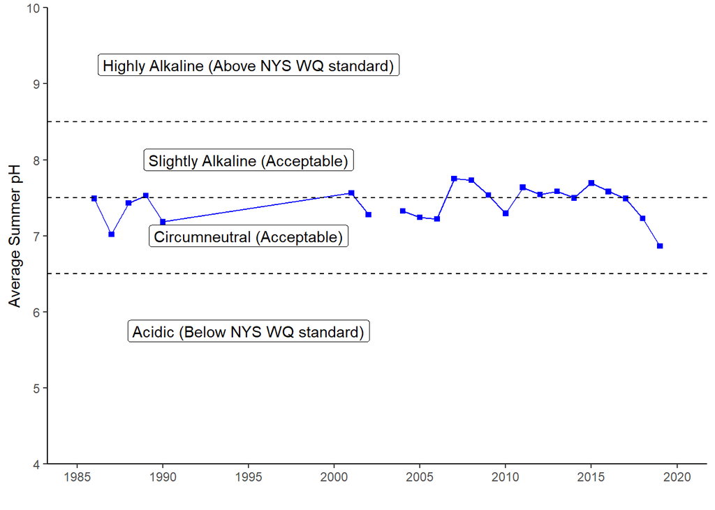

#### Specific Conductance

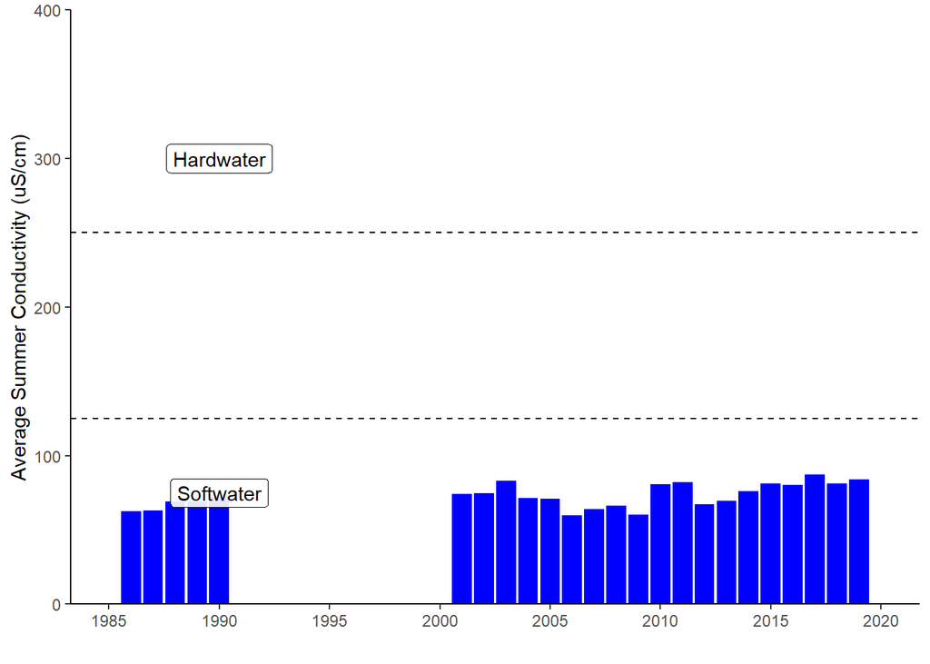

#### Calcium

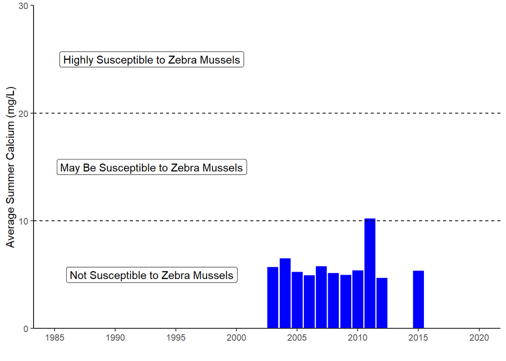

#### Chloride

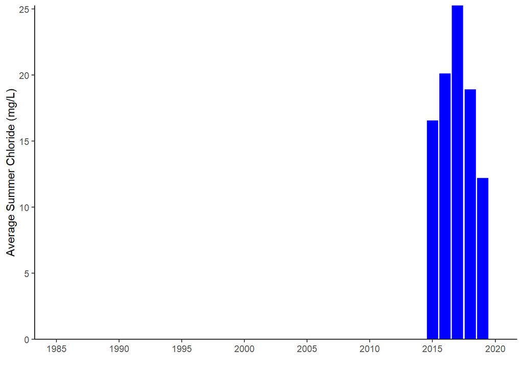

#### Color

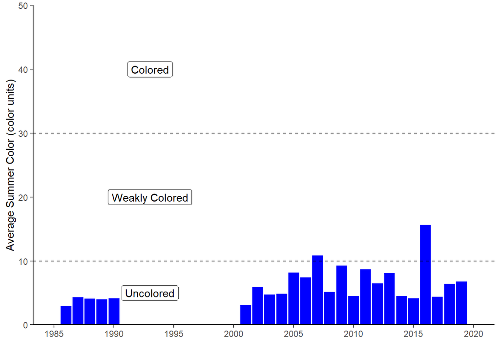

#### Surface and Deep Temperature

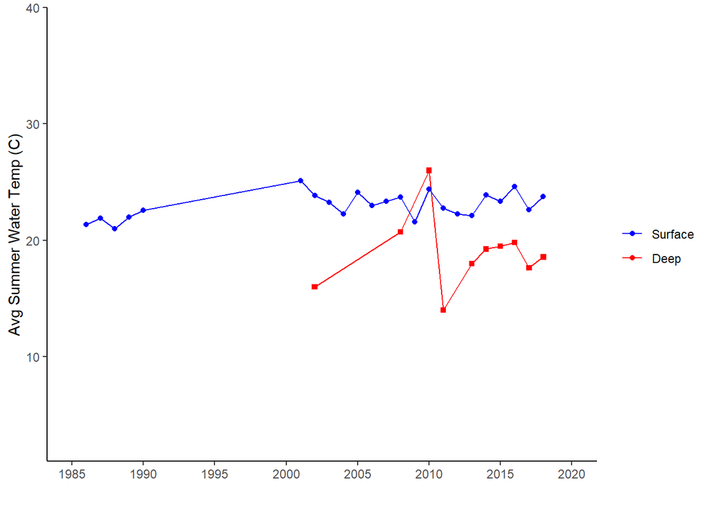

#### Lake Perception

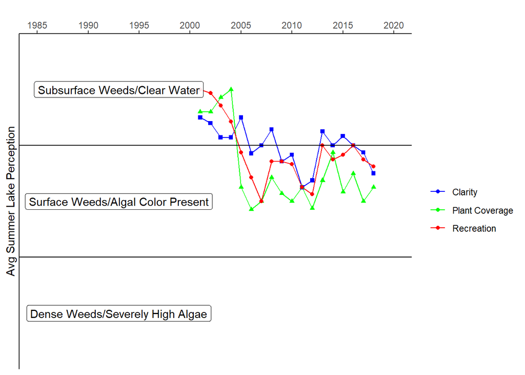

## Lake Petonia - In-Season Analysis

#### In Season Water Clarity

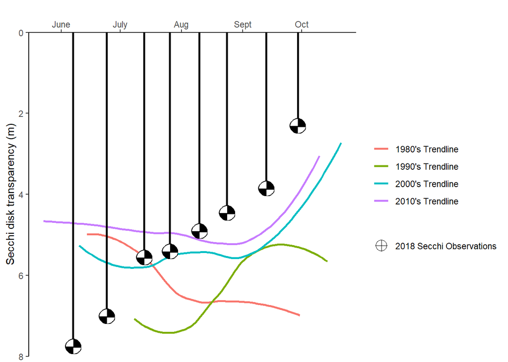

#### In Season Water Temperature

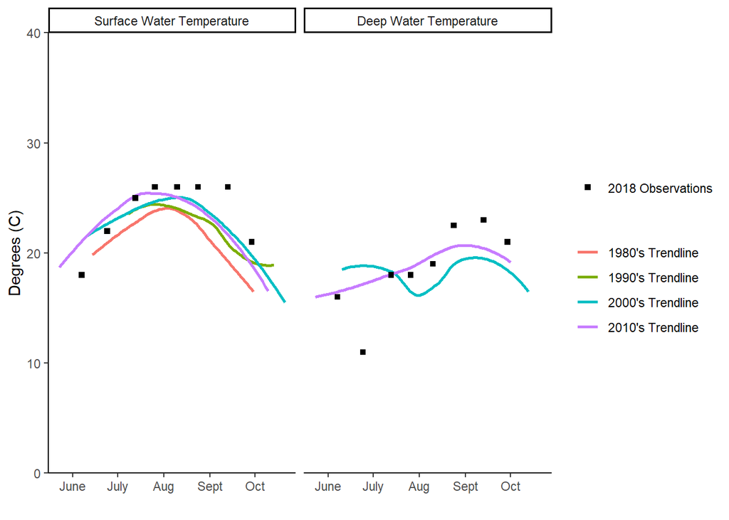